# Lydia_ModelFinal

### **Step 2 — Residual & Assumption Review (Individual)**

check the residual diagnostics and assumption of the final model

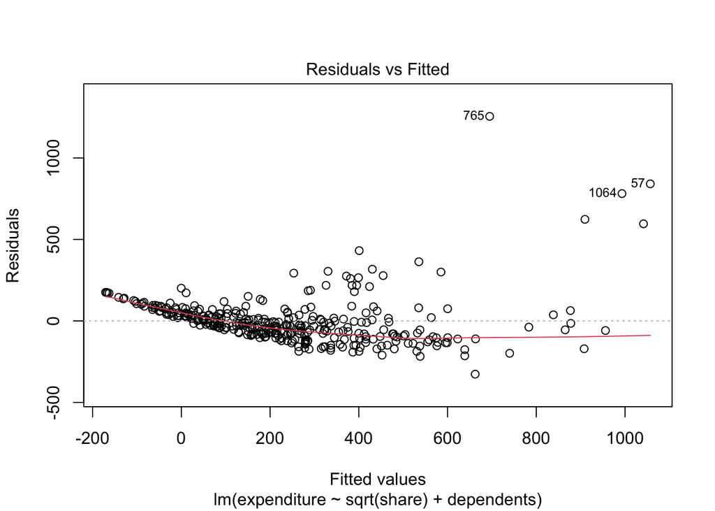

```r
plot(final_model, which=1) # residuals vs fitted
```

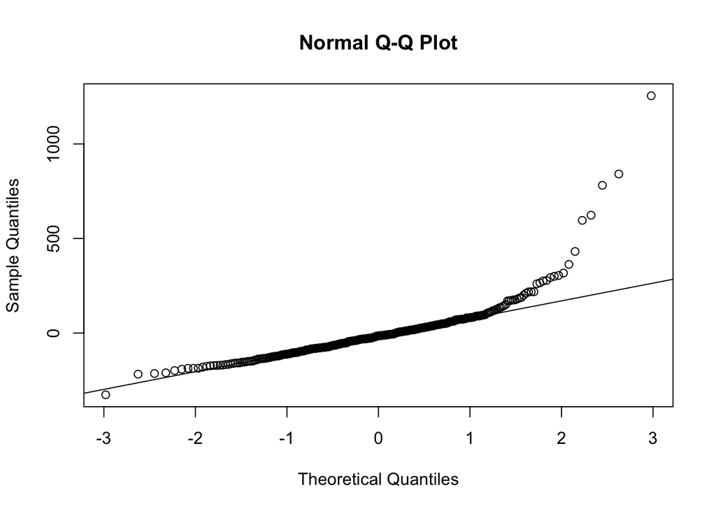

```r
qqnorm(resid(final_model)); qqline(resid(final_model)) # normality
```

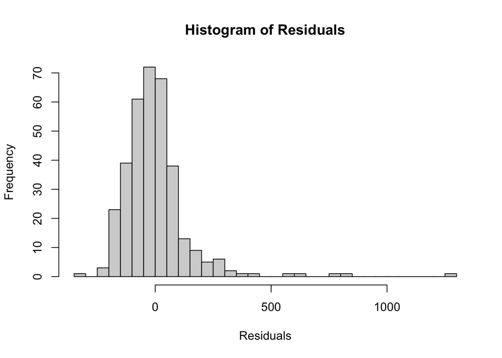

```r
res <- residuals(final_model)
hist(res,
     main = "Histogram of Residuals",
     xlab = "Residuals",
     breaks = 30)
```

```r
dwtest(final_model)
```

```
##
##  Durbin-Watson test
##
## data:  final_model
## DW = 2.1222, p-value = 0.8751
## alternative hypothesis: true autocorrelation is greater than 0
```

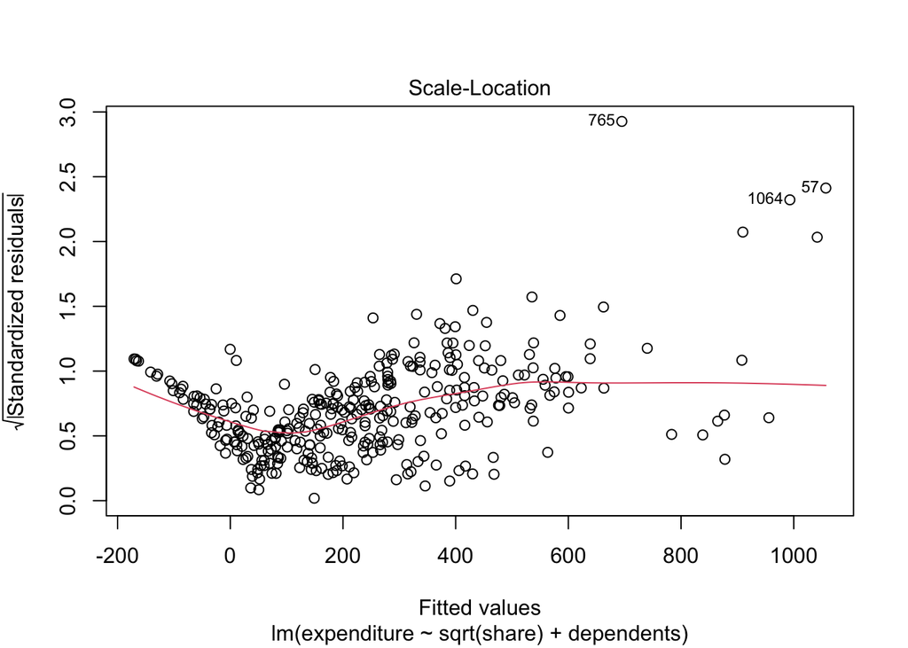

```r
plot(final_model, which = 3) # Scale-Location Plot (Checks homoscedasticity/constant variance)
```

```r
# Standardized Residuals and Outlier Detection
# Create standardized residuals for the final model
rstandard_final <- rstandard(final_model)
```

After cleaning the data and simplifying our transformed model, we observed improvements in model performance, but several key assumptions still remained unmet. The Residuals vs. Fitted plot still shows curvilinear patterns, suggesting lingering model misspecification, and the qq plot reveals deviation in the upper tail, indicating that normality is still violated. Because we have already explored transformations on both the response and predictors, the next logical step is to address potential outliers that may be contributing to these issues.